# Norwegian Hydro Power Generation — Forecasting Analysis

## 12.6 CCF

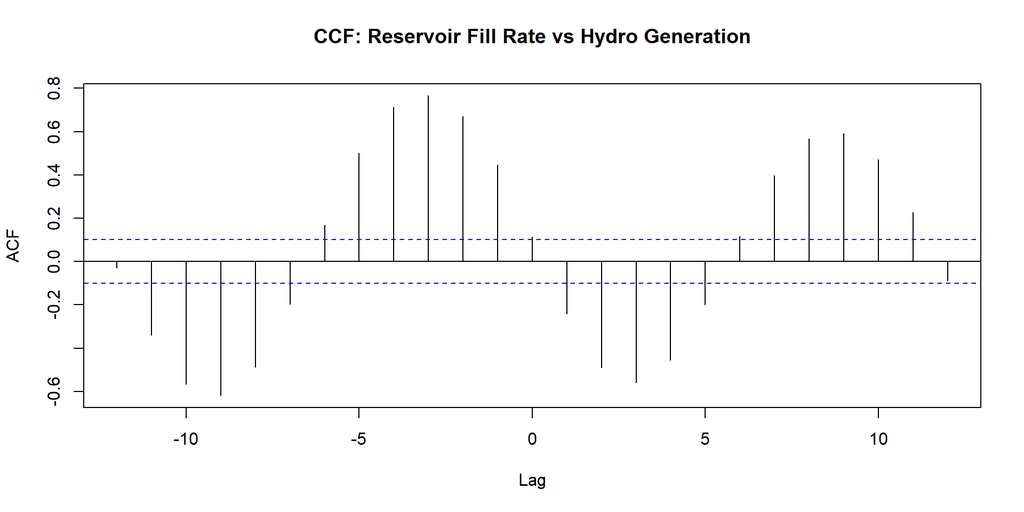

```r
ccf_data <- reservoir_fill_rate %>%
  as_tibble() %>%
  filter(!is.na(fill_rate_pct), !is.na(TWh))

ccf(ccf_data$fill_rate_pct, ccf_data$TWh,
    lag.max = 12,
    main = "CCF: Reservoir Fill Rate vs Hydro Generation")
```

```r
# Create seasonally differenced series for CCF
ccf_diff_data <- reservoir_fill_rate %>%
  as_tibble() %>%
  mutate(
    TWh_sdiff = difference(TWh, lag = 12),
    fill_rate_sdiff = difference(fill_rate_pct, lag = 12)
  ) %>%
  filter(!is.na(TWh_sdiff), !is.na(fill_rate_sdiff))

# CCF on differenced series
ccf(
  ccf_diff_data$fill_rate_sdiff,
  ccf_diff_data$TWh_sdiff,
  lag.max = 12,
  main = "CCF: Fill Rate vs Hydro Generation (seasonally differenced)"
)
```

[figure not shown]

```r
# Confirm stationarity after differencing
cat("=== ADF: Hydro (seasonally differenced) ===\n")
```

```
## === ADF: Hydro (seasonally differenced) ===
```

```r
adf.test(ccf_diff_data$TWh_sdiff)
```

```
##
##  Augmented Dickey-Fuller Test
##
## data:  ccf_diff_data$TWh_sdiff
## Dickey-Fuller = -5.57, Lag order = 7, p-value = 0.01
## alternative hypothesis: stationary
```

```r
cat("\n=== ADF: Fill Rate (seasonally differenced) ===\n")
```

```
##
## === ADF: Fill Rate (seasonally differenced) ===
```

```r
adf.test(ccf_diff_data$fill_rate_sdiff)
```

```
##
##  Augmented Dickey-Fuller Test
##
## data:  ccf_diff_data$fill_rate_sdiff
## Dickey-Fuller = -6.862, Lag order = 7, p-value = 0.01
## alternative hypothesis: stationary
```

Both series reject non-stationarity strongly (p = 0.01, the minimum reportable value). This confirms that seasonal differencing was sufficient to achieve stationarity in both hydro generation and fill rate.

## 12.7 Correlation Test

```r
cat("=== Pearson Correlation: Fill Rate (lag 1) vs Hydro ===\n")
```

```
## === Pearson Correlation: Fill Rate (lag 1) vs Hydro ===
```

```r
cor.test(reservoir_fill_rate$fill_rate_pct_lag1,
         reservoir_fill_rate$TWh,
         method = "pearson")
```

```
##
##  Pearson's product-moment correlation
##
## data:  reservoir_fill_rate$fill_rate_pct_lag1 and reservoir_fill_rate$TWh
## t = 9.6268, df = 372, p-value < 2.2e-16
## alternative hypothesis: true correlation is not equal to 0
## 95 percent confidence interval:
##  0.3615533 0.5242511
## sample estimates:
##       cor
## 0.4465863
```

**Description:** r = 0.447 → moderate positive linear correlation between last month’s fill rate and this month’s hydro generation.

## 12.8 Preparing Data for Granger and VAR

```r
# Prepare data for Granger and VAR

var_tsibble <- reservoir_fill_rate %>%
  mutate(
    TWh_sdiff = difference(TWh, lag = 12),
    fill_rate_sdiff = difference(fill_rate_pct, lag = 12)
  ) %>%
  filter(!is.na(TWh_sdiff), !is.na(fill_rate_sdiff)) %>%
  select(Month, TWh_sdiff, fill_rate_sdiff)
```

## 12.9 Plot Seasonally Differenced Series

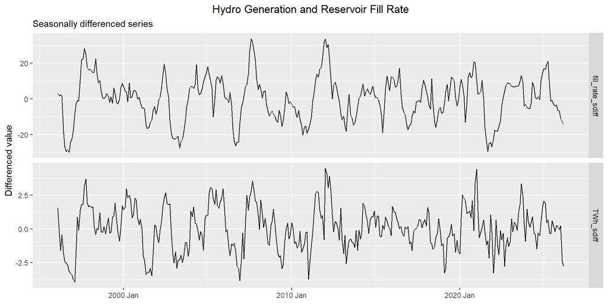

```r
# Plot seasonally differenced series

var_tsibble %>%
  pivot_longer(
    cols = c(TWh_sdiff, fill_rate_sdiff),
    names_to = "variable",
    values_to = "value"
  ) %>%
  ggplot(aes(x = Month, y = value)) +
  geom_line() +
  facet_grid(vars(variable), scales = "free_y") +
  labs(
    title = "Hydro Generation and Reservoir Fill Rate",
    subtitle = "Seasonally differenced series",
    x = NULL,
    y = "Differenced value"
  ) +
  theme(plot.title = element_text(hjust = 0.5))
```

## 12.10 Granger Test

```r
# Granger causality tests

granger_data <- var_tsibble %>%
  as.data.frame()

cat("\n=== Granger Test: Fill Rate -> Hydro ===\n")
```

```
##
## === Granger Test: Fill Rate -> Hydro ===
```

```r
grangertest(TWh_sdiff ~ fill_rate_sdiff,
            order = 1,
            data = granger_data)
```

```
## Granger causality test
##
## Model 1: TWh_sdiff ~ Lags(TWh_sdiff, 1:1) + Lags(fill_rate_sdiff, 1:1)
## Model 2: TWh_sdiff ~ Lags(TWh_sdiff, 1:1)
##   Res.Df Df      F    Pr(>F)
## 1    358
## 2    359 -1 86.269 < 2.2e-16 ***
## ---
## Signif. codes:  0 '***' 0.001 '**' 0.01 '*' 0.05 '.' 0.1 ' ' 1
```

```r
cat("\n=== Granger Test: Hydro -> Fill Rate ===\n")
```

```
##
## === Granger Test: Hydro -> Fill Rate ===
```

```r
grangertest(fill_rate_sdiff ~ TWh_sdiff,
            order = 1,
            data = granger_data)
```

```
## Granger causality test
##
## Model 1: fill_rate_sdiff ~ Lags(fill_rate_sdiff, 1:1) + Lags(TWh_sdiff, 1:1)
## Model 2: fill_rate_sdiff ~ Lags(fill_rate_sdiff, 1:1)
##   Res.Df Df      F Pr(>F)
## 1    358
## 2    359 -1 5.4962 0.0196 *
## ---
## Signif. codes:  0 '***' 0.001 '**' 0.01 '*' 0.05 '.' 0.1 ' ' 1
```

**Interpretation:** The Granger causality tests indicate a strongly significant predictive relationship from reservoir fill rate to hydro generation (F = 86.269, p < 0.001). This suggests that last month’s reservoir fill rate contains substantial information for predicting current hydro generation beyond the series’ own history. The reverse direction is also statistically significant but much weaker (F = 5.4962, p = 0.0196), indicating some bidirectional predictive relationship. However, the dominant predictive channel runs from reservoir fill rate to hydro generation.

## 12.11 VAR Modelling

```r
# VAR models
fit_var <- var_tsibble %>%
  model(
    aicc = fable::VAR(vars(TWh_sdiff, fill_rate_sdiff)),
    bic  = fable::VAR(vars(TWh_sdiff, fill_rate_sdiff), ic = "bic")
  )

fit_var
```

```
## # A mable: 1 x 2
##       aicc      bic
##    <model>  <model>
## 1 <VAR(5)> <VAR(2)>
```

**Interpretation:** AICC –> Prefers richer model, better for forecasting BIC –> Penalises complexity more, prefers parsimony

## 12.12 Compare VAR models

```r
# Compare VAR models

glance(fit_var) %>%
  select(.model, AIC, AICc, BIC) %>%
  arrange(AICc)
```

```
## # A tibble: 2 × 4
##   .model   AIC  AICc   BIC
##   <chr>  <dbl> <dbl> <dbl>
## 1 aicc   3133. 3137. 3226.
## 2 bic    3174. 3175. 3221.
```

**Interpretation:** The information criteria compare the AICc-selected VAR model with the BIC-selected VAR model. Lower values indicate a better trade-off between model fit and complexity. The AICc model has the lowest AIC and AICc, so it is preferred if the goal is forecasting. The BIC model has the lowest BIC, meaning it is more parsimonious and penalizes complexity more strongly. For this project, the AICc model is more relevant for forecast performance, while the BIC model is useful as a simpler robustness check.

## 12.13 VAR Coefficients

```r
fit_var %>%
  tidy() %>%
  select(.model, term, .response, estimate, std.error, statistic, p.value)
```

```
## # A tibble: 28 × 7
##    .model term                   .response estimate std.error statistic  p.value
##    <chr>  <chr>                  <chr>        <dbl>     <dbl>     <dbl>    <dbl>
##  1 aicc   lag(TWh_sdiff,1)       TWh_sdiff  0.601     0.0538     11.2   6.05e-25
##  2 aicc   lag(fill_rate_sdiff,1) TWh_sdiff  0.0896    0.00959     9.34  1.17e-18
##  3 aicc   lag(TWh_sdiff,2)       TWh_sdiff -0.0463    0.0628     -0.737 4.62e- 1
##  4 aicc   lag(fill_rate_sdiff,2) TWh_sdiff -0.0715    0.0157     -4.55  7.41e- 6
##  5 aicc   lag(TWh_sdiff,3)       TWh_sdiff  0.0694    0.0631      1.10  2.72e- 1
##  6 aicc   lag(fill_rate_sdiff,3) TWh_sdiff  0.0267    0.0167      1.60  1.11e- 1
##  7 aicc   lag(TWh_sdiff,4)       TWh_sdiff -0.116     0.0618     -1.88  6.13e- 2
##  8 aicc   lag(fill_rate_sdiff,4) TWh_sdiff  0.00601   0.0162      0.372 7.10e- 1
##  9 aicc   lag(TWh_sdiff,5)       TWh_sdiff  0.0108    0.0501      0.216 8.29e- 1
## 10 aicc   lag(fill_rate_sdiff,5) TWh_sdiff -0.00509   0.0109     -0.466 6.42e- 1
## # ℹ 18 more rows
```

**Interpretation:** The VAR coefficient estimates show that reservoir fill rate contains significant predictive information for hydro generation. In both the AICc and BIC specifications, the first lag of reservoir fill rate enters the hydro equation positively and is highly statistically significant. Hydro generation is also strongly persistent, as its own first lag is positive and significant in both models. In the fill-rate equation, the strongest effects come from the fill rate’s own lagged values, indicating substantial persistence in reservoir conditions. Overall, the coefficient estimates support the Granger causality results: the dominant predictive channel runs from reservoir fill rate to hydro generation, although some bidirectional dynamics are also present.

## 12.14 Residual Diagnostics: Hydro Equation

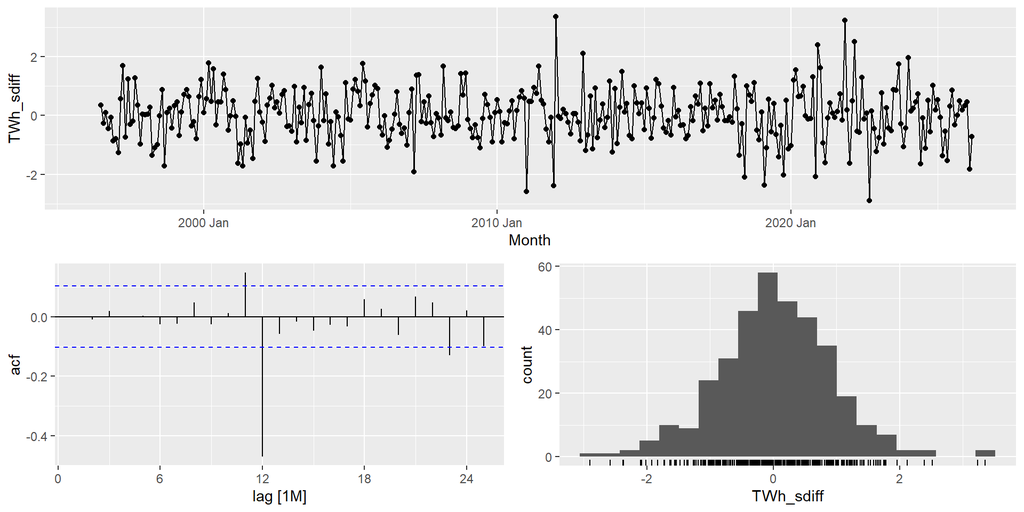

```r
fit_var %>%
  select(aicc) %>%
  residuals() %>%
  gg_tsdisplay(TWh_sdiff, plot_type = "hist")
```

**Interpretation:** The residual diagnostics for the hydro equation show that most residuals fluctuate around zero, which is desirable. However, the ACF plot shows a clear significant spike at lag 12. This indicates that some seasonal autocorrelation remains in the hydro residuals, meaning the VAR model has not fully captured the annual seasonal pattern. The histogram is roughly centered around zero but shows some extreme observations, suggesting occasional hydro shocks remain unexplained. Overall, the VAR captures part of the dynamics, but the residuals are not fully white noise.

## 12.15 Residual diagnostics: Fill Rate Equation

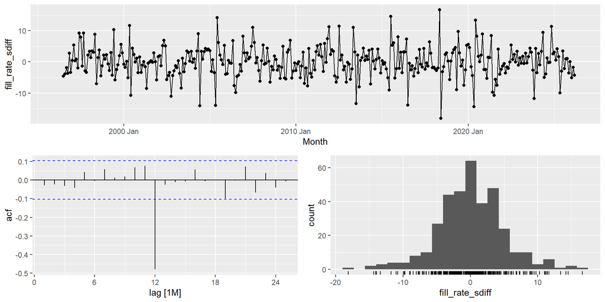

```r
fit_var %>%
  select(aicc) %>%
  residuals() %>%
  gg_tsdisplay(fill_rate_sdiff, plot_type = "hist")
```

**Interpretation:** The residual diagnostics for the fill-rate equation show that the residuals fluctuate around zero, which is generally desirable. However, the ACF plot shows a clear significant spike at lag 12. This indicates that some annual seasonal autocorrelation remains in the residuals. The histogram is roughly centered around zero but has relatively wide tails, suggesting that some larger reservoir shocks remain unexplained. Overall, the VAR captures part of the fill-rate dynamics, but the residuals are not fully white noise.

## 12.16 ARIMAX

```r
train_arimax_fill_rate <- reservoir_fill_rate %>%
  filter(Month <= max(Month) - 24)

test_arimax_fill_rate <- reservoir_fill_rate %>%
  filter(Month > max(Month) - 24)

fit_arimax_fill_rate <- train_arimax_fill_rate %>%
  model(
    ARIMAX_Auto = ARIMA(
      TWh ~ fill_rate_pct_lag1
    )
  )

glance(fit_arimax_fill_rate)
```

```
## # A tibble: 1 × 8
##   .model      sigma2 log_lik   AIC  AICc   BIC ar_roots   ma_roots
##   <chr>        <dbl>   <dbl> <dbl> <dbl> <dbl> <list>     <list>
## 1 ARIMAX_Auto  0.487   -363.  739.  740.  766. <cpl [13]> <cpl [25]>
```

## 12.17 Model Insights: Fill Rate

This section evaluates whether reservoir fill rate improves the forecasting model.

```r
# 1. Inspect the selected ARIMAX model
fit_arimax_fill_rate %>%
  select(ARIMAX_Auto) %>%
  report()
```

```
## Series: TWh
## Model: LM w/ ARIMA(1,0,1)(1,1,2)[12] errors
##
## Coefficients:
##          ar1     ma1     sar1     sma1     sma2  fill_rate_pct_lag1
##       0.6192  0.0829  -0.3725  -0.5083  -0.2620              0.0872
## s.e.  0.0767  0.0930   0.6665   0.6753   0.5715              0.0084
##
## sigma^2 estimated as 0.4872:  log likelihood=-362.66
## AIC=739.31   AICc=739.65   BIC=766.07
```

```r
coef_arimax_fill_rate <- tidy(fit_arimax_fill_rate) %>%
  filter(.model == "ARIMAX_Auto")

coef_arimax_fill_rate %>%
  select(term, estimate, std.error, statistic, p.value) %>%
  kable(
    digits  = 4,
    align   = "c",
    caption = "ARIMAX_Auto coefficient estimates — fill rate regressor"
  )
```

ARIMAX_Auto coefficient estimates — fill rate regressor

| term | estimate | std.error | statistic | p.value |
| --- | --- | --- | --- | --- |
| ar1 | 0.6192 | 0.0767 | 8.0771 | 0.0000 |
| ma1 | 0.0829 | 0.0930 | 0.8915 | 0.3733 |
| sar1 | -0.3725 | 0.6665 | -0.5588 | 0.5766 |
| sma1 | -0.5083 | 0.6753 | -0.7526 | 0.4522 |
| sma2 | -0.2620 | 0.5715 | -0.4584 | 0.6470 |
| fill_rate_pct_lag1 | 0.0872 | 0.0084 | 10.3900 | 0.0000 |

```r
# 2. Forecast performance of ARIMAX
fc_arimax_fill_rate <- fit_arimax_fill_rate %>%
  forecast(new_data = test_arimax_fill_rate)

accuracy(fc_arimax_fill_rate, reservoir_fill_rate) %>%
  select(.model, RMSE, MAE, MAPE, MASE) %>%
  arrange(MASE) %>%
  kable(
    digits  = 3,
    align   = "c",
    caption = "Forecast accuracy of ARIMAX fill rate model"
  )
```

Forecast accuracy of ARIMAX fill rate model

| .model | RMSE | MAE | MAPE | MASE |
| --- | --- | --- | --- | --- |
| ARIMAX_Auto | 0.841 | 0.656 | 5.506 | 0.5 |

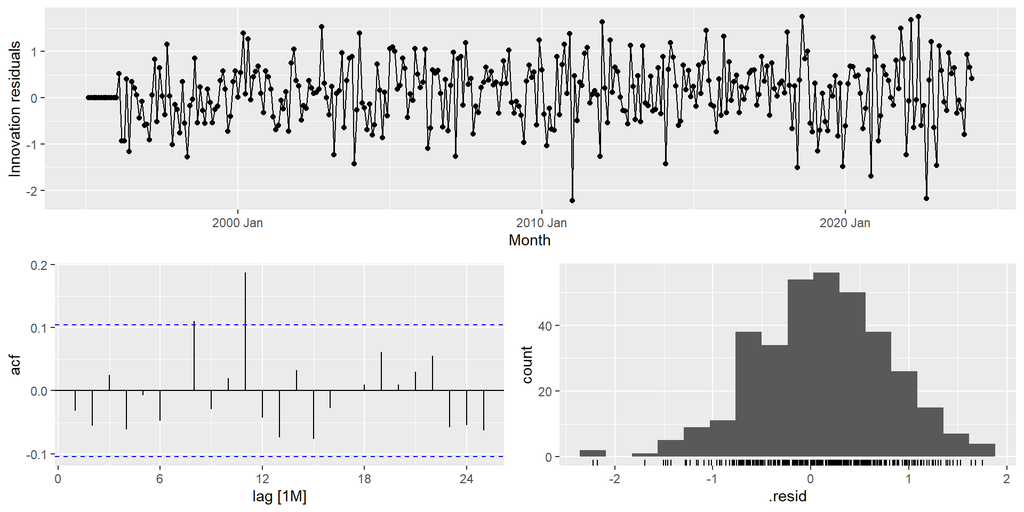

```r
# 3. Residual diagnostics for the selected ARIMAX model
fit_arimax_fill_rate %>%
  select(ARIMAX_Auto) %>%
  gg_tsresiduals()
```

```r
lb_arimax_fill_rate_auto <- augment(fit_arimax_fill_rate %>% select(ARIMAX_Auto)) %>%
  features(.innov, ljung_box, lag = 24, dof = 5)

lb_arimax_fill_rate_auto
```

```
## # A tibble: 1 × 3
##   .model      lb_stat lb_pvalue
##   <chr>         <dbl>     <dbl>
## 1 ARIMAX_Auto    32.3    0.0293
```

```r
lb_arimax_fill_rate_auto_dof6 <- augment(fit_arimax_fill_rate %>% select(ARIMAX_Auto)) %>%
  features(.innov, ljung_box, lag = 24, dof = 6)

lb_arimax_fill_rate_auto_dof6
```

```
## # A tibble: 1 × 3
##   .model      lb_stat lb_pvalue
##   <chr>         <dbl>     <dbl>
## 1 ARIMAX_Auto    32.3    0.0205
```

```r
# 4. Refit benchmark model on the common ARIMAX sample
fit_common_fill_rate <- train_arimax_fill_rate %>%
  model(
    ARIMAX_Auto    = ARIMA(TWh ~ fill_rate_pct_lag1)
  )

glance(fit_common_fill_rate) %>%
  select(.model, sigma2, log_lik, AIC, AICc, BIC) %>%
  arrange(AICc) %>%
  kable(
    digits  = 3,
    align   = "c",
    caption = "Information criteria — common sample, fill rate regressor"
  )
```

Information criteria — common sample, fill rate regressor

| .model | sigma2 | log_lik | AIC | AICc | BIC |
| --- | --- | --- | --- | --- | --- |
| ARIMAX_Auto | 0.487 | -362.656 | 739.311 | 739.65 | 766.072 |

```r
# 5. Final out-of-sample forecast comparison
fc_common_fill_rate <- fit_common_fill_rate %>%
  forecast(new_data = test_arimax_fill_rate)

accuracy(fc_common_fill_rate, reservoir_fill_rate) %>%
  select(.model, RMSE, MAE, MAPE, MASE) %>%
  arrange(MASE) %>%
  kable(
    digits  = 3,
    align   = "c",
    caption = "Forecast accuracy on the common 24-month test set — fill rate"
  )
```

Forecast accuracy on the common 24-month test set — fill rate

| .model | RMSE | MAE | MAPE | MASE |
| --- | --- | --- | --- | --- |
| ARIMAX_Auto | 0.841 | 0.656 | 5.506 | 0.5 |

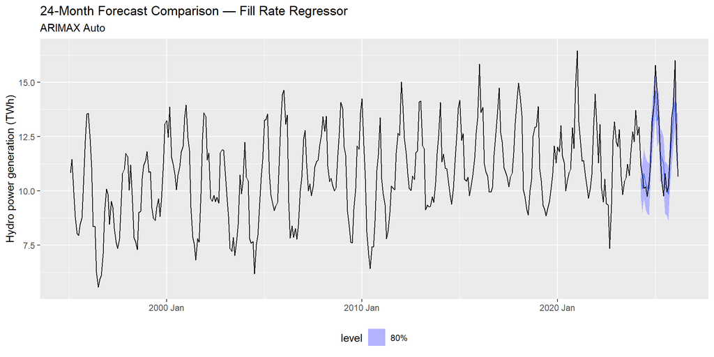

```r
# 6. Forecast plot
fc_common_fill_rate %>%
  filter(.model %in% c("ETS", "Airline_SARIMA", "ARIMAX_Auto")) %>%
  autoplot(reservoir_fill_rate, level = 80) +
  labs(
    title    = "24-Month Forecast Comparison — Fill Rate Regressor",
    subtitle = "ARIMAX Auto",
    y        = "Hydro power generation (TWh)",
    x        = NULL
  ) +
  theme(legend.position = "bottom")
```

## 12.18 Comparing ARIMAX and VAR

```r
# === Step 1: Refit VAR on training data only ===
train_end <- max(train_arimax_fill_rate$Month)

var_train <- var_tsibble %>%
  filter(Month <= train_end)

fit_var_train <- var_train %>%
  model(aicc = fable::VAR(vars(TWh_sdiff, fill_rate_sdiff)))

# === Step 2: Forecast 24 months ahead ===
fc_var <- fit_var_train %>%
  forecast(h = 24)

fc_var_tidy <- fc_var %>%
  as_tibble() %>%
  mutate(
    TWh_sdiff_mean       = .mean[, 1],
    fill_rate_sdiff_mean = .mean[, 2]
  )

# === Step 3: Anchor — last 12 actual TWh before train_end, shifted forward 12 months ===
# Anchor: 24 months immediately before the forecast period starts
last_actual <- reservoir_fill_rate %>%
  as_tibble() %>%
  arrange(Month) %>%
  filter(Month > train_end - 24, Month <= train_end) %>%
  select(Month, TWh) %>%
  mutate(Month = Month + 24)  # shift forward 24 to align with forecast months

cat("VAR forecast months:\n"); print(fc_var_tidy %>% filter(.model == "aicc") %>% pull(Month))
```

```
## VAR forecast months:
```

```
## <yearmonth[24]>
##  [1] "2024 Apr"  "2024 May"  "2024 Jun"  "2024 Jul"  "2024 Aug"  "2024 Sept"
##  [7] "2024 Oct"  "2024 Nov"  "2024 Dec"  "2025 Jan"  "2025 Feb"  "2025 Mar"
## [13] "2025 Apr"  "2025 May"  "2025 Jun"  "2025 Jul"  "2025 Aug"  "2025 Sept"
## [19] "2025 Oct"  "2025 Nov"  "2025 Dec"  "2026 Jan"  "2026 Feb"  "2026 Mar"
```

```r
cat("Anchor months:\n"); print(last_actual$Month)
```

```
## Anchor months:
```

```
## <yearmonth[24]>
##  [1] "2024 Apr"  "2024 May"  "2024 Jun"  "2024 Jul"  "2024 Aug"  "2024 Sept"
##  [7] "2024 Oct"  "2024 Nov"  "2024 Dec"  "2025 Jan"  "2025 Feb"  "2025 Mar"
## [13] "2025 Apr"  "2025 May"  "2025 Jun"  "2025 Jul"  "2025 Aug"  "2025 Sept"
## [19] "2025 Oct"  "2025 Nov"  "2025 Dec"  "2026 Jan"  "2026 Feb"  "2026 Mar"
```

```r
# === Step 4: Invert seasonal difference ===
fc_var_levels <- fc_var_tidy %>%
  filter(.model == "aicc") %>%
  left_join(last_actual, by = "Month") %>%
  mutate(TWh_forecast = TWh_sdiff_mean + TWh)

cat("NAs in TWh_forecast:", sum(is.na(fc_var_levels$TWh_forecast)), "\n")
```

```
## NAs in TWh_forecast: 0
```

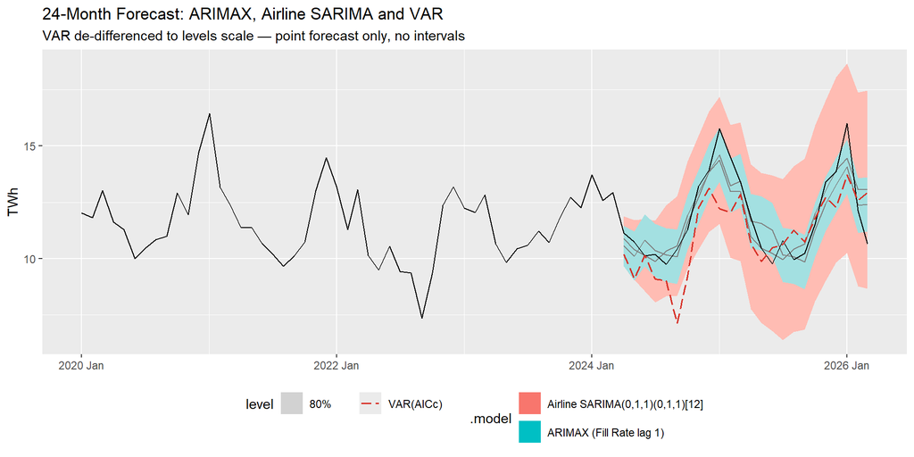

```r
# === Step 5: Rebuild ARIMAX forecast ===
fc_common_fill_rate <- fit_arimax_fill_rate %>%
  forecast(new_data = test_arimax_fill_rate)

# === Step 6: Plot ===
bind_rows(
  fc_common_fill_rate %>%
    mutate(.model = recode(.model,
      "ARIMAX_Auto" = "ARIMAX (Fill Rate lag 1)"
    )),
  fc %>%
    filter(.model == "Airline_SARIMA") %>%
    mutate(.model = "Airline SARIMA(0,1,1)(0,1,1)[12]")
) %>%
  autoplot(
    reservoir_fill_rate %>%
      filter(Month >= yearmonth("2020 Jan")),
    level = 80
  ) +
  geom_line(
    data = fc_var_levels,
    aes(x = Month, y = TWh_forecast, colour = "VAR(AICc)"),
    linewidth = 0.7, linetype = "longdash"
  ) +
  scale_colour_manual(values = c("VAR(AICc)" = "#d73027")) +
  labs(
    title    = "24-Month Forecast: ARIMAX, Airline SARIMA and VAR",
    subtitle = "VAR de-differenced to levels scale — point forecast only, no intervals",
    y        = "TWh", x = NULL,
    colour   = NULL
  ) +
  theme(legend.position = "bottom") +
  guides(colour = guide_legend(nrow = 2, byrow = TRUE),
         fill   = guide_legend(nrow = 2, byrow = TRUE))
```

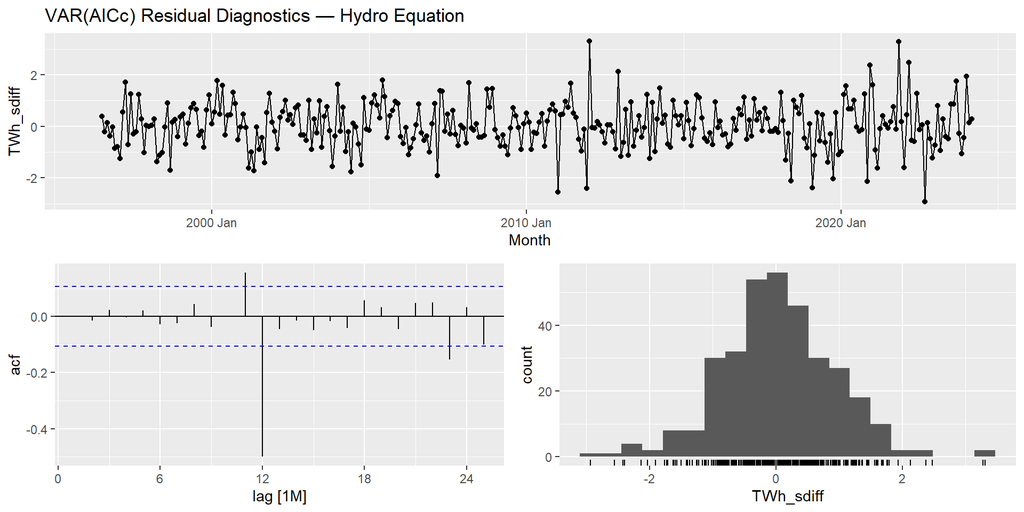

```r
# VAR residual diagnostics — hydro equation
fit_var_train %>%
  residuals() %>%
  gg_tsdisplay(TWh_sdiff, plot_type = "hist") +
  labs(title = "VAR(AICc) Residual Diagnostics — Hydro Equation")
```

```r
# Ljung-Box test on hydro equation residuals
fit_var_train %>%
  residuals() %>%
  features(TWh_sdiff, ljung_box, lag = 24, dof = 5) %>%
  kable(digits = 4,
        col.names = c("Model", "Q-statistic", "p-value"),
        caption = "Ljung-Box Test: VAR(AICc) Hydro Equation (lag = 24, dof = 5)")
```

Ljung-Box Test: VAR(AICc) Hydro Equation (lag = 24, dof = 5)

| Model | Q-statistic | p-value |
| --- | --- | --- |
| aicc | 112.5031 | 0 |

# 13 Appendix — Save Processed Data

```r
write_csv(total_elec %>% as_tibble(), "data/total_electricity_norway.csv")
write_csv(hydro       %>% as_tibble(), "data/hydro_norway.csv")

cat("Files saved:\n- total_electricity_norway.csv\n- hydro_norway.csv\n")
```

```
## Files saved:
## - total_electricity_norway.csv
## - hydro_norway.csv
```